# Flight summaries

## Read in Petra’s data

> Need to tidy the dataframe as it comes in to R in a strange format. I am using the here package. When you run “library(here)” above you will see in your console a message that says: “here() starts at C:/Users…..”. I put your data in a folder called “in_development”. So you will need to change that bit of the code (just the last section) to your folder. OR you can just use the “path” approach. Also check the deliminator - excel on my computer changes “,” to “;” and I need to use “;” as the deliminator in the read_delim function.

```r
df_e <- read_delim(paste0(here::here(),"/in_development/df_e.csv"),";", escape_double = FALSE, trim_ws = TRUE) # need to change the directory here to the correct path on your computer
#df_e<_read_delim("path", "delim", escape_double = FALSE, trim_ws = TRUE)

all_dfs=df_e %>%
  select(!X1)# Drop the first column that has been imported from EXCEL - check that this is also the case for you

all_dfs=all_dfs %>%
  mutate(
    time = format(time, "%H:%M:%S")
    ) # fix time format
```

## Draw the flight paths for all flights

```r
library(leaflet)
pal <- colorFactor(
  palette = 'Dark2',
  domain = all_dfs$Flight
)


leaflet(data=all_dfs[,c(5,4, 18)]) %>%
  addTiles() %>%
  addCircleMarkers(lng=~lon_dec, lat=~lat_dec, radius=2, color = ~pal(Flight))
```

[interactive chart not shown]

## Draw the flight paths for each flight

```r
library(leaflet)
ldat1=all_dfs %>%
  filter(Flight=="Flight1")
leaflet(data=ldat1[,c(5,4)]) %>%
  addTiles() %>%
  addCircleMarkers(lng=~lon_dec, lat=~lat_dec, radius=2)
```

[interactive chart not shown]

```r
library(leaflet)
ldat1=all_dfs %>%
  filter(Flight=="Flight2")
leaflet(data=ldat1[,c(5,4)]) %>%
  addTiles() %>%
  addCircleMarkers(lng=~lon_dec, lat=~lat_dec, radius=2)
```

[interactive chart not shown]

```r
library(leaflet)
ldat1=all_dfs %>%
  filter(Flight=="Flight3")
leaflet(data=ldat1[,c(5,4)]) %>%
  addTiles() %>%
  addCircleMarkers(lng=~lon_dec, lat=~lat_dec, radius=2)
```

[interactive chart not shown]

```r
library(leaflet)
ldat1=all_dfs %>%
  filter(Flight=="Flight4")
leaflet(data=ldat1[,c(5,4)]) %>%
  addTiles() %>%
  addCircleMarkers(lng=~lon_dec, lat=~lat_dec, radius=2)
```

[interactive chart not shown]

```r
library(leaflet)
ldat1=all_dfs %>%
  filter(Flight=="Flight5")
leaflet(data=ldat1[,c(5,4)]) %>%
  addTiles() %>%
  addCircleMarkers(lng=~lon_dec, lat=~lat_dec, radius=2)
```

[interactive chart not shown]

```r
library(leaflet)
ldat1=all_dfs %>%
  filter(Flight=="Flight6")
leaflet(data=ldat1[,c(5,4)]) %>%
  addTiles() %>%
  addCircleMarkers(lng=~lon_dec, lat=~lat_dec, radius=2)
```

[interactive chart not shown]

```r
library(leaflet)
ldat1=all_dfs %>%
  filter(Flight=="Flight7")
leaflet(data=ldat1[,c(5,4)]) %>%
  addTiles() %>%
  addCircleMarkers(lng=~lon_dec, lat=~lat_dec, radius=2)
```

[interactive chart not shown]

```r
library(leaflet)
ldat1=all_dfs %>%
  filter(Flight=="Flight8")
leaflet(data=ldat1[,c(5,4)]) %>%
  addTiles() %>%
  addCircleMarkers(lng=~lon_dec, lat=~lat_dec, radius=2)
```

[interactive chart not shown]

At this point you could add the altitude from the DEM [see the “Getting raster values form a Digital Elevation Model” vignette]. Here, for this example, we will use the column called Altitude above the ground (*because we can not include all the DEMs we would need inside the package*).

## Strip-width summary

```r
 all_dfs=all_dfs%>%
    group_by(Flight) %>%
  filter(!str_detect(photo_no, "IMG")) %>% # remove empty photos
  rowwise() %>%
  mutate("strip_width"=Kulan::get_strip_width(alt_above_ground))
 our_summary1 <-
  list("strip width" =
         list("min"       = ~ round(min(strip_width)),
              "max"       = ~ round(max(strip_width)),
              "mean (sd)" = ~ qwraps2::mean_sd(strip_width)))


tab_1<-qwraps2::summary_table(dplyr::group_by(all_dfs, Flight),our_summary1)
tab_1
```

|  | Flight1 (N = 1676) | Flight2 (N = 1504) | Flight3 (N = 1410) | Flight4 (N = 1641) | Flight5 (N = 1511) | Flight6 (N = 1915) | Flight7 (N = 1457) | Flight8 (N = 1536) |
| --- | --- | --- | --- | --- | --- | --- | --- | --- |
| **strip width** |  |  |  |  |  |  |  |  |
| min | -18 | -17 | -11 | -13 | -15 | -15 | -11 | -5 |
| max | 534 | 610 | 553 | 539 | 581 | 580 | 560 | 603 |
| mean (sd) | 504.05 ± 30.95 | 516.72 ± 35.13 | 514.73 ± 26.99 | 507.09 ± 23.60 | 508.10 ± 36.72 | 494.87 ± 63.88 | 533.03 ± 35.65 | 527.57 ± 27.74 |

## Remove points where the drone is in take-off or landing

### First plot the data

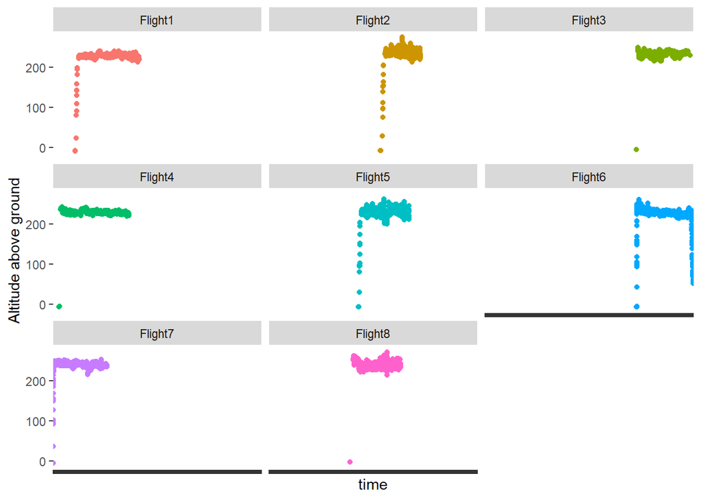

```r
all_dfs %>%
  ggplot(aes(time, alt_above_ground, colour=Flight)) +
  labs(y= "Altitude above ground")+
  theme(axis.text.x = element_blank())+
  geom_point()+
  theme(legend.position = "None")+
  facet_wrap(~Flight)
```

From the distribution of the altitudes we can see that anything below 200 m is probably take-off or landing phase.

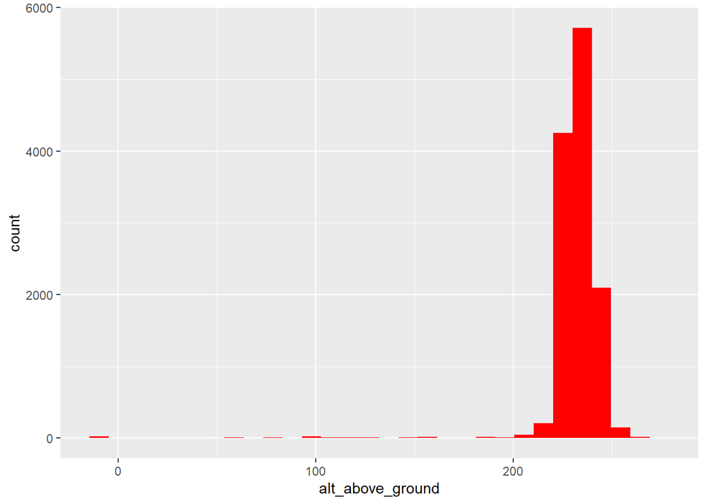

```r
all_dfs %>%
  ggplot(aes(alt_above_ground))+
  geom_histogram(fill="Red")
```

However, we might want to look more closely at Flight5 as it seems some of the points during the flight are below 200m.

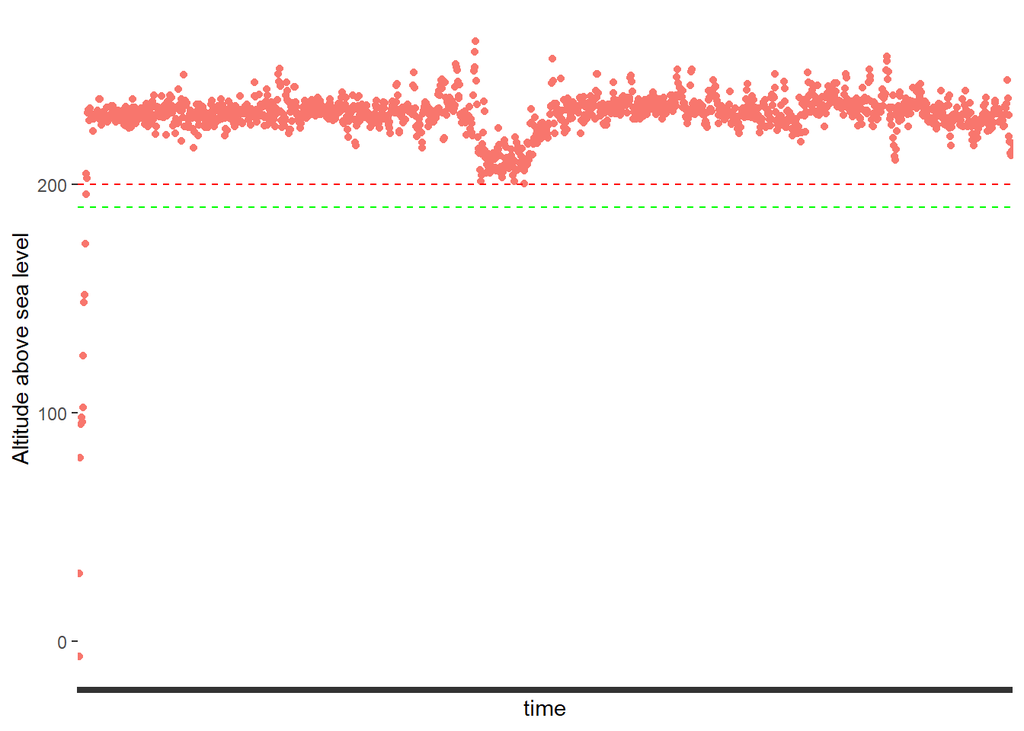

```r
all_dfs %>%
  filter(Flight=="Flight5") %>%
  ggplot(aes(time, alt_above_ground, colour=Flight)) +
  labs(y= "Altitude above sea level")+
  theme(axis.text.x = element_blank())+
  geom_point()+
  geom_hline(yintercept = 200, colour="Red", lty=2) +
  geom_hline(yintercept = 190, colour="Green", lty=2) +
  theme(legend.position = "None")
```

So a couple of points in Flight5 during the actual flight were below our threshold of 200m. So let’s be conservative and go for 190m instead. You can change this threshold by changing the value in the code below.

```r
all_dfs_reduced=all_dfs %>%
  filter(alt_above_ground>190)# The threshold is controlled here - change it by changing the number from 190
```

Now all the points in consideration are above 190m.Let’s re-run the strip-width summary.

|  | Flight1 (N = 1664) | Flight2 (N = 1491) | Flight3 (N = 1407) | Flight4 (N = 1638) | Flight5 (N = 1498) | Flight6 (N = 1822) | Flight7 (N = 1443) | Flight8 (N = 1533) |
| --- | --- | --- | --- | --- | --- | --- | --- | --- |
| **strip width** |  |  |  |  |  |  |  |  |
| min | 432 | 452 | 478 | 488 | 433 | 423 | 425 | 476 |
| max | 534 | 610 | 553 | 539 | 581 | 580 | 560 | 603 |
| mean (sd) | 506.30 ± 9.76 | 519.47 ± 13.36 | 515.85 ± 11.79 | 508.05 ± 7.95 | 510.92 ± 16.92 | 507.85 ± 14.08 | 536.05 ± 11.27 | 528.61 ± 14.64 |

## Altitude above ground summary

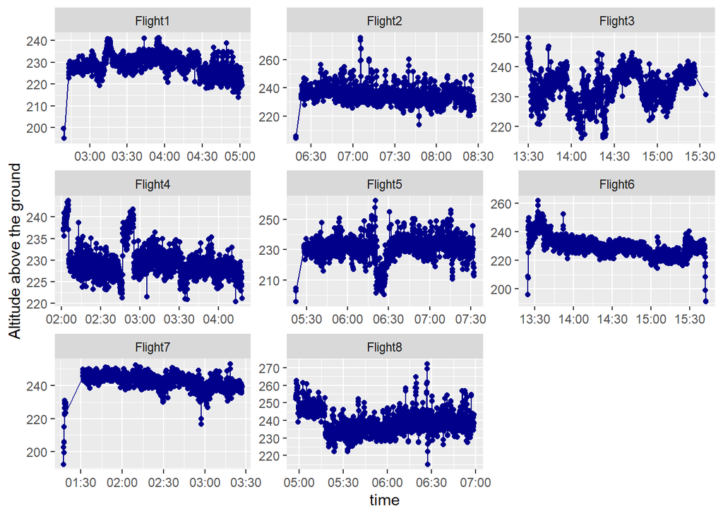

```r
all_dfs_reduced %>%
   mutate(time2=as.POSIXct(time,format="%H:%M:%S")) %>%
  ggplot(aes(time2,alt_above_ground))+
  geom_point(colour="darkblue")+
  geom_line(colour="darkblue", group=1)+
  labs(x="time", y="Altitude above the ground")+
  facet_wrap(Flight~., scale="free")
```

## Speed summary

Using the gps_speed we can plot the speed of the drone during each flight.

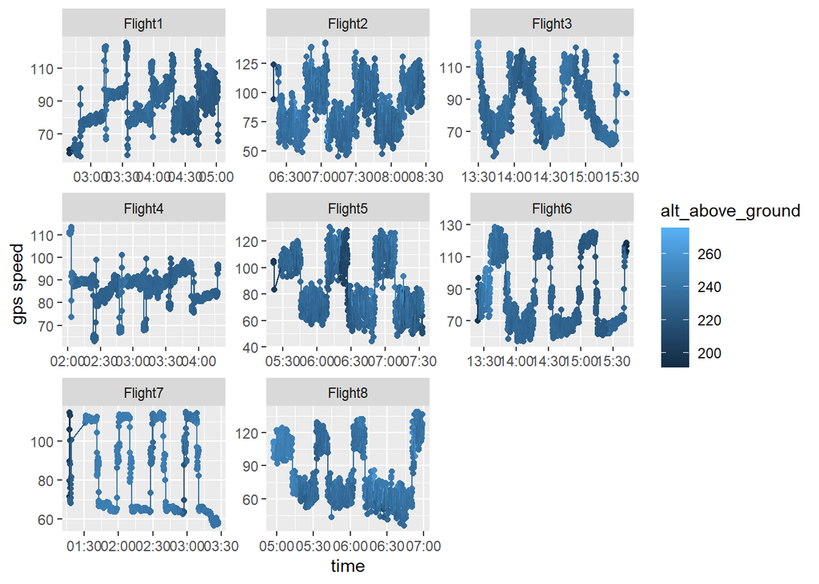

```r
all_dfs_reduced%>%
  mutate(rowid=row_number()) %>%
  mutate(time2=as.POSIXct(time,format="%H:%M:%S")) %>%
  #ggplot(aes(time2,gps_speed))+# replace the next line with this to remove the alt_above_ground colour
  ggplot(aes(time2,gps_speed,colour=alt_above_ground))+
  geom_point()+
  geom_line()+
  labs(x="time", y= "gps speed")+
  #geom_point(colour="darkblue")+# add these lines too and remove the two above
  #geom_line(colour="darkblue")+#
  facet_wrap(~Flight, scales="free")
```

## Distance between points summary

There are some very large distances moved at the start or the end of a Flight and these need to be filtered out to allow us to plot the distance more clearly. Anything above 250m is therefore removed in the plotting code below.The points are coloured by the gps_speed.

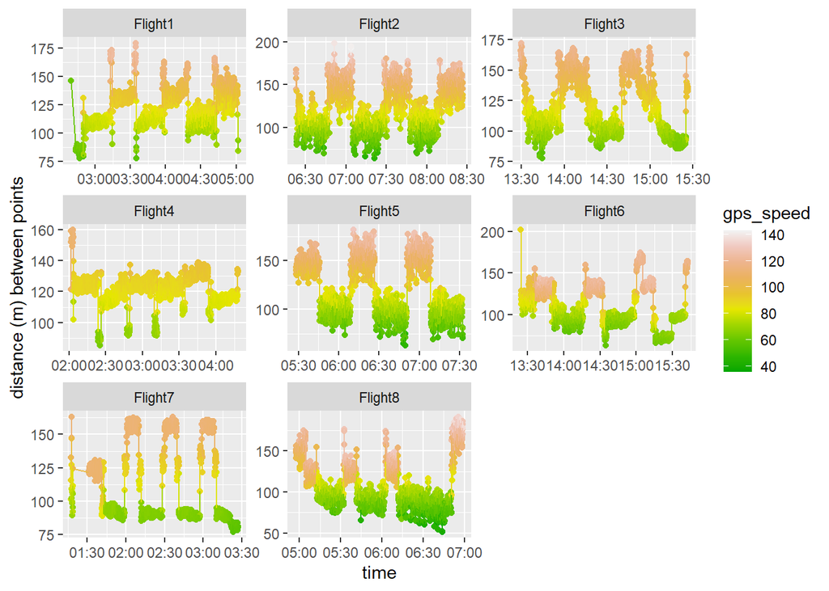

```r
distance_df=all_dfs_reduced%>%
  group_by(Flight) %>%
  mutate(new_lat=lag(lat_dec)) %>%
  mutate(new_lon=lag(lon_dec)) %>%
  rowwise() %>%
  mutate(coord_dif=distm(c(lon_dec, lat_dec), c(new_lon, new_lat), fun = distHaversine))

distance_df %>%
  group_by(Flight) %>%
  mutate(time2=as.POSIXct(time,format="%H:%M:%S")) %>%
  filter(coord_dif<250) %>%
  ggplot(aes(time2,coord_dif,colour=gps_speed))+
  geom_point()+
  geom_line()+
  scale_colour_gradientn(colours = terrain.colors(10))+
  labs(x= "time",y="distance (m) between points")+
  facet_wrap(~Flight, scales="free")
```

## Banking Angle

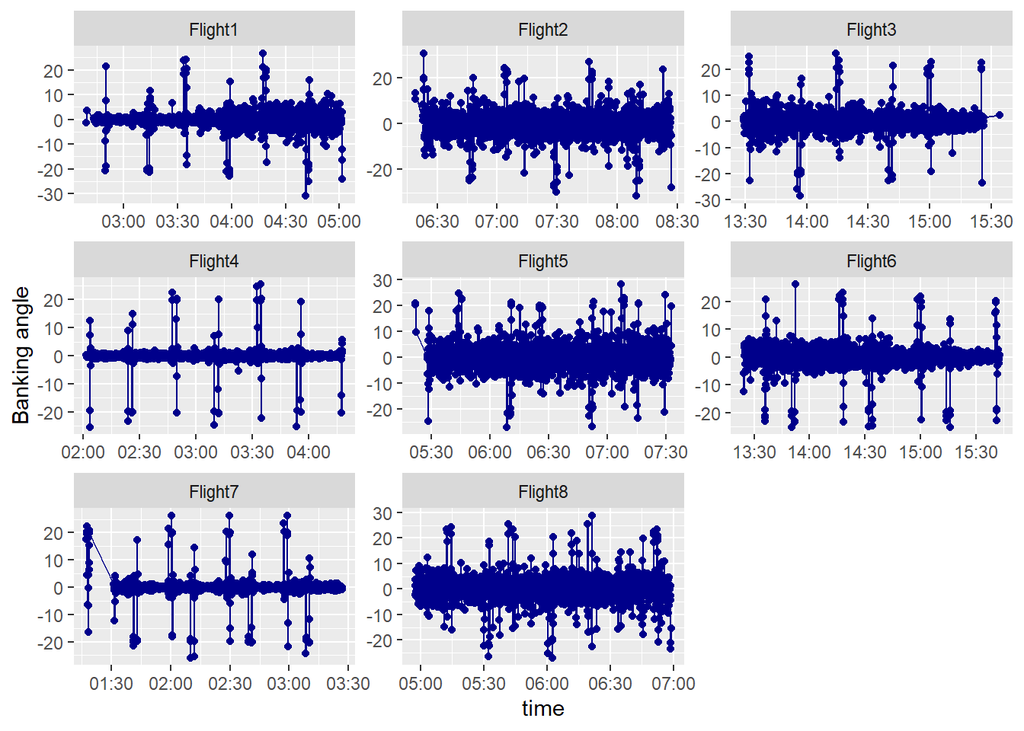

```r
all_dfs_reduced%>%
  mutate(rowid=row_number()) %>%
  mutate(time2=as.POSIXct(time,format="%H:%M:%S")) %>%
  ggplot(aes(time2,banking_angle))+
  geom_point(colour="darkblue")+
  geom_line(colour="darkblue")+
  labs(x="time", y="Banking angle")+
  facet_wrap(~Flight, scales="free")
```

## Overlap

The forward overlap is the percentage overlap that two consecutive images have.

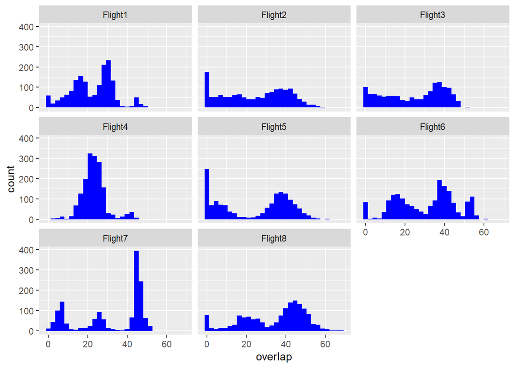

```r
over=distance_df %>%
group_by(Flight) %>%
rowwise() %>%
mutate(overlap=Kulan::oforward( dforwar=coord_dif[,1],H=alt_above_ground ))

over %>%
  mutate(overlap=ifelse(overlap<0,0,overlap)) %>% # this makes any overlap less than 0 == 0
  ggplot(aes(overlap)) +
  geom_histogram(fill="blue")+
  facet_wrap(~Flight)
```

The mean overlap per Flight is

```r
over %>%
  mutate(overlap=ifelse(overlap<0,0,overlap)) %>% # this makes any overlap less than 0 == 0
  group_by(Flight) %>%
  summarise(mnOver=mean(overlap, na.rm=TRUE))
```

```
## # A tibble: 8 x 2
##   Flight  mnOver
## * <chr>    <dbl>
## 1 Flight1   22.5
## 2 Flight2   24.6
## 3 Flight3   24.7
## 4 Flight4   23.2
## 5 Flight5   24.1
## 6 Flight6   30.6
## 7 Flight7   32.0
## 8 Flight8   34.5
```

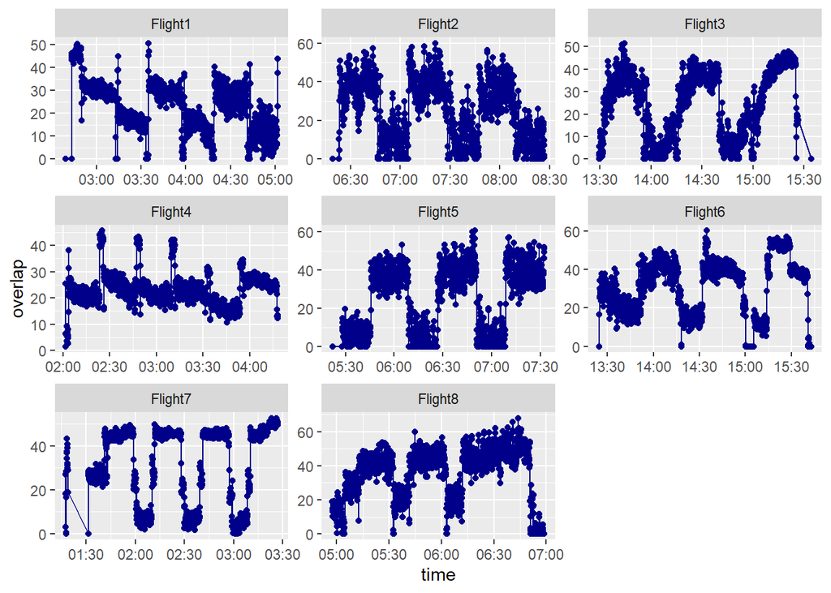

```r
over %>%
  mutate(overlap=ifelse(overlap<0,0,overlap)) %>% # this makes any overlap less than 0 == 0
  mutate(time=as.POSIXct(time,format="%H:%M:%S")) %>%
  ggplot(aes(time,overlap)) +
  geom_point(colour="darkblue")+
  geom_line(colour="darkblue")+
  facet_wrap(~Flight, scales = "free")
```

## Ground surface resolution

*Need to check this function - I am using the formula from https://www.mdpi.com/2072-4292/11/10/1252/htm with cosine correction for angle*

```r
GSR_all_dfs=all_dfs_reduced %>%
  rowwise() %>%
  mutate("GSR"=get_GSD_dist(Altitude = alt_above_ground, Angle = banking_angle))

GSR_all_dfs$GSR
```

[output not shown]

[output cut: 12482 more lines]

```r
df=GSR_all_dfs %>%
  group_by(Flight) %>%
  group_split()

resolution=data.frame("Flight"=c("Flight1","Flight2","Flight3","Flight4","Flight5","Flight6","Flight7","Flight8"), "DGS_far"= c(mean(df[[1]]$GSR$GSD),mean(df[[2]]$GSR$GSD),mean(df[[3]]$GSR$GSD),mean(df[[4]]$GSR$GSD),mean(df[[5]]$GSR$GSD),mean(df[[6]]$GSR$GSD),mean(df[[7]]$GSR$GSD),mean(df[[8]]$GSR$GSD)),"DGS_near"= c(mean(df[[1]]$GSR$GSDc),mean(df[[2]]$GSR$GSDc),mean(df[[3]]$GSR$GSDc),mean(df[[4]]$GSR$GSDc),mean(df[[5]]$GSR$GSDc),mean(df[[6]]$GSR$GSDc),mean(df[[7]]$GSR$GSDc),mean(df[[8]]$GSR$GSDc)))
```

## Generate summary ouputs

### Flight summary table

```r
output_summary_table=all_dfs_reduced %>%
  group_by(Flight) %>%
  summarise(Date=min(date),  Time_start=min(time), Time_end=max(time), Mean_Altitude=mean(alt_above_ground, na.rm=TRUE), SD_Altitude=sd(alt_above_ground, na.rm=TRUE), Mean_GPS_Speed= mean(gps_speed, na.rm=TRUE),SD_GPS_Speed= sd(gps_speed, na.rm=TRUE), Mean_Banking= mean(banking_angle, na.rm=TRUE),SD_Banking= sd(banking_angle, na.rm=TRUE), Mean_Strip_Width=mean(strip_width, na.rm=TRUE), SD_Strip_width=sd(strip_width, na.rm=TRUE))

over_sum=over %>%
  group_by(Flight) %>%
  summarise(Mean_Overlap=mean(overlap, na.rm=TRUE), SD_Overlap=sd(overlap, na.rm=TRUE))

no_photos=all_dfs_reduced %>%
  group_by(Flight) %>%
  tally()

output_summary_table=output_summary_table %>% inner_join(over_sum)
output_summary_table=output_summary_table %>% inner_join(resolution)
output_summary_table =output_summary_table %>% inner_join(no_photos)
output_summary_table %>%
  rename(.,"no_of_photos"="n")
```

```
## # A tibble: 8 x 17
##   Flight  Date      Time_start Time_end Mean_Altitude SD_Altitude Mean_GPS_Speed
##   <chr>   <chr>     <chr>      <chr>            <dbl>       <dbl>          <dbl>
## 1 Flight1 16.07.20~ 02:39:12   05:01:43          229.        4.41           87.3
## 2 Flight2 16.07.20~ 06:19:00   08:26:52          235.        6.03           87.7
## 3 Flight3 16.07.20~ 13:29:24   15:34:09          233.        5.33           86.6
## 4 Flight4 17.07.20~ 02:01:37   04:18:01          230.        3.59           86.9
## 5 Flight5 17.07.20~ 05:21:48   07:32:28          231.        7.65           86.9
## 6 Flight6 17.07.20~ 13:24:26   15:42:51          229.        6.36           88.0
## 7 Flight7 18.07.20~ 01:17:22   03:26:59          242.        5.09           83.7
## 8 Flight8 18.07.20~ 04:57:29   06:58:56          239.        6.61           83.2
## # ... with 10 more variables: SD_GPS_Speed <dbl>, Mean_Banking <dbl>,
## #   SD_Banking <dbl>, Mean_Strip_Width <dbl>, SD_Strip_width <dbl>,
## #   Mean_Overlap <dbl>, SD_Overlap <dbl>, DGS_far <dbl>, DGS_near <dbl>,
## #   no_of_photos <int>
```

```r
# You can write the table to .csv using this code below
#write.csv(output_summary_table, "Summary_per_flight.csv")
```

```r
kableExtra::kable(output_summary_table) %>%
  kableExtra::kable_styling()
```

| Flight | Date | Time_start | Time_end | Mean_Altitude | SD_Altitude | Mean_GPS_Speed | SD_GPS_Speed | Mean_Banking | SD_Banking | Mean_Strip_Width | SD_Strip_width | Mean_Overlap | SD_Overlap | DGS_far | DGS_near | n |
| --- | --- | --- | --- | --- | --- | --- | --- | --- | --- | --- | --- | --- | --- | --- | --- | --- |
| Flight1 | 16.07.2020 | 02:39:12 | 05:01:43 | 228.7544 | 4.411047 | 87.32683 | 12.285448 | -0.2927885 | 3.956929 | 506.3003 | 9.762356 | 20.95582 | 59.979575 | 2.957394 | 2.781431e+14 | 1664 |
| Flight2 | 16.07.2020 | 06:19:00 | 08:26:52 | 234.7057 | 6.034842 | 87.74318 | 19.593855 | -0.2454058 | 5.884572 | 519.4714 | 13.356077 | 21.08624 | 115.871058 | 3.034333 | 4.773860e+14 | 1491 |
| Flight3 | 16.07.2020 | 13:29:24 | 15:34:09 | 233.0707 | 5.327431 | 86.57092 | 17.137485 | -0.0968017 | 4.392054 | 515.8531 | 11.790463 | 19.17553 | 202.123767 | 3.013196 | 3.432813e+14 | 1407 |
| Flight4 | 17.07.2020 | 02:01:37 | 04:18:01 | 229.5429 | 3.591580 | 86.85670 | 6.893593 | -0.1415751 | 3.079227 | 508.0454 | 7.948744 | 23.16235 | 6.123844 | 2.967587 | 3.011169e+00 | 1638 |
| Flight5 | 17.07.2020 | 05:21:48 | 07:32:28 | 230.8400 | 7.645962 | 86.89314 | 20.920840 | 0.0208945 | 5.678644 | 510.9160 | 16.921744 | 19.74466 | 140.161251 | 2.984356 | 4.632000e+14 | 1498 |
| Flight6 | 17.07.2020 | 13:24:26 | 15:42:51 | 229.4549 | 6.361421 | 87.99036 | 23.550376 | -0.0798573 | 4.119754 | 507.8507 | 14.078848 | 30.01671 | 18.469468 | 2.966450 | 2.438178e+14 | 1822 |
| Flight7 | 18.07.2020 | 01:17:22 | 03:26:59 | 242.1969 | 5.093805 | 83.69114 | 21.970004 | 0.0120582 | 4.293970 | 536.0506 | 11.273409 | 22.74167 | 351.056722 | 3.131181 | 3.584603e+13 | 1443 |
| Flight8 | 18.07.2020 | 04:57:29 | 06:58:56 | 238.8353 | 6.612866 | 83.15225 | 25.291078 | -0.1504240 | 5.441415 | 528.6109 | 14.635338 | 34.16157 | 16.197715 | 3.087722 | 5.791103e+14 | 1533 |

### Export to excel

```r
Export_2_excel=over %>%
  mutate(strip_width_1_side=strip_width/2)

Export_2_excel$DGS_near=GSR_all_dfs$GSR$GSDw
Export_2_excel$DGS_far=GSR_all_dfs$GSR$GSDh


Export_2_excel=Export_2_excel %>%
  select(!c("new_lat","new_lon"))# removes these columns as they are only used for calculating over values

# You can write this table to excel by running this line (delete the "comment" '#' symbol)
#write.csv(Export_2_excel, "Flight_data.csv")
```